# R Notebook

The first thing to do it to find out how the hell to analyse data

```r
library(corrplot)
library(tidyverse)
library(ggplot2)
library(maps)
library(ggmap)
library(tmap)
library(geosphere)
library(lubridate)
library(sf)
library(dplyr)
library(lubridate)
```

```r
trips_df <- read_csv("../data/trips_data_cleaned.csv")
```

The goal is to find how members and casual users differ in behavior.

#Lost bikes vs not lost bikes

First question I have is with lost bikes. Do casuals lose more more bikes than members?

```r
trips_df_no_lost <- trips_df  %>%
  select(everything()) %>%
  filter(end_station_name != "Lost")
```

```r
trips_df_lost <- trips_df  %>%
  select(everything()) %>%
  filter(end_station_name == "Lost")
```

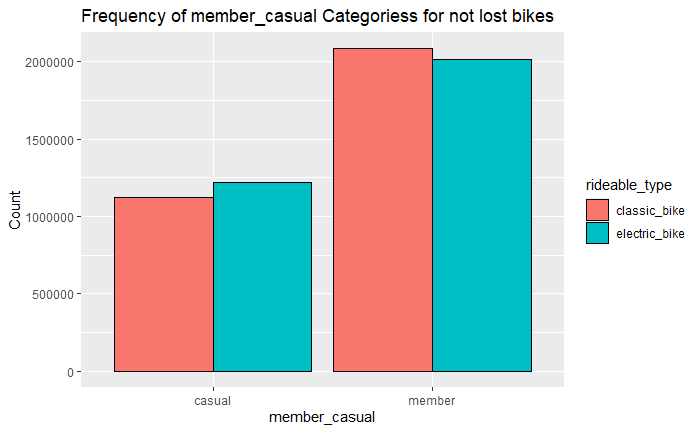

```r
ggplot(trips_df_no_lost, aes(x = member_casual, fill = rideable_type)) +
    geom_bar(color = "black", position = "dodge") +
    labs(title = "Frequency of member_casual Categoriess for not lost bikes", x = "member_casual", y = "Count")
```

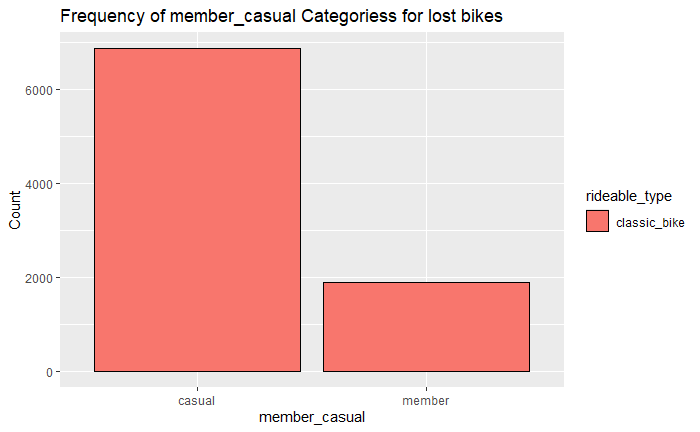

```r
ggplot(trips_df_lost, aes(x = member_casual, fill = rideable_type)) +
    geom_bar(color = "black", position = "dodge") +
    labs(title = "Frequency of member_casual Categoriess for lost bikes", x = "member_casual", y = "Count")
```

Most of the lost bikes are used by casuals despite the casual population being about half of the member population. One thing to note is that for the lost bikes everything is red because only classic bikes can be lost since electric bikes have integrated GPS into them.

As a recommendation A good focus for future analysis is finding why casual users lose more bikes than members and use that for promoting the membership. Or find ways to avoid casual users from losing the bikes,

#Analysing trip durations.

```r
trips_df_no_lost %>%
  select(member_casual, trip_duration) %>%  # Select only relevant columns
  group_by(member_casual) %>%               # Group by member vs casual
  summarise(
    min_trip_duration = min(trip_duration, na.rm = TRUE),
    first_quartile = quantile(trip_duration, 0.25, na.rm = TRUE),
    median_trip_duration = median(trip_duration, na.rm = TRUE),
    mean_trip_duration = mean(trip_duration, na.rm = TRUE),
    third_quartile = quantile(trip_duration, 0.75, na.rm = TRUE),
    max_trip_duration = max(trip_duration, na.rm = TRUE)
  )
```

| member_casual | min_trip_duration | first_quartile | median_trip_duration | mean_trip_duration | third_quartile | max_trip_duration |
| --- | --- | --- | --- | --- | --- | --- |
| casual | 0.0017333349 | 6.816667 | 12.233333 | 21.21378 | 22.80000 | 1439.833 |
| member | 0.0006499966 | 5.111904 | 8.766667 | 12.36406 | 14.96667 | 1439.867 |

```r
NA
```

There are still some big outliers even removing trips that lasted 24 hours or longer. So I will use IQR to remove the outliers.

```r
Q1 <- quantile(trips_df_no_lost$trip_duration, 0.25)
Q3 <- quantile(trips_df_no_lost$trip_duration, 0.75)
IQR <- Q3 - Q1

# Define outliers as values outside 1.5 * IQR from Q1 and Q3
lower_bound <- Q1 - 1.5 * IQR
upper_bound <- Q3 + 1.5 * IQR

# Filter outliers
trips_no_outliers <- trips_df_no_lost %>% filter(trip_duration > lower_bound & trip_duration < upper_bound)
```

```r
trips_no_outliers %>%
  select(member_casual, trip_duration) %>%  # Select only relevant columns
  group_by(member_casual) %>%               # Group by member vs casual
  summarise(
    min_trip_duration = min(trip_duration, na.rm = TRUE),
    first_quartile = quantile(trip_duration, 0.25, na.rm = TRUE),
    median_trip_duration = median(trip_duration, na.rm = TRUE),
    mean_trip_duration = mean(trip_duration, na.rm = TRUE),
    third_quartile = quantile(trip_duration, 0.75, na.rm = TRUE),
    max_trip_duration = max(trip_duration, na.rm = TRUE)
  )
```

| member_casual | min_trip_duration | first_quartile | median_trip_duration | mean_trip_duration | third_quartile | max_trip_duration |
| --- | --- | --- | --- | --- | --- | --- |
| casual | 0.0017333349 | 6.183333 | 10.53333 | 12.42604 | 17.26667 | 35.09952 |
| member | 0.0006499966 | 4.983333 | 8.45000 | 10.37876 | 13.96667 | 35.09935 |

```r
NA
```

After removing ouliers all trips are bellow 35 minutes with some of them still being shorter than 1 minute. I don’t have minimum length for trips so I will work with this limit.

```r
trips_no_outliers %>%
  count()
```

| n |
| --- |
| 5969914 |

```r
trips_df %>%
  count()
```

| n |
| --- |
| 6451628 |

```r
NA
```

481,714 rows were removed .

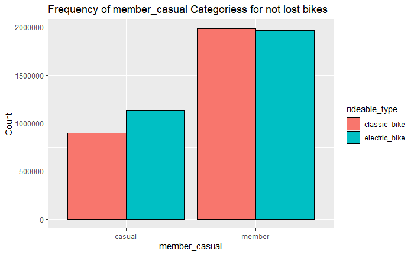

```r
ggplot(trips_no_outliers, aes(x = member_casual, fill = rideable_type)) +
    geom_bar(color = "black", position = "dodge") +
    labs(title = "Frequency of member_casual Categoriess for not lost bikes", x = "member_casual", y = "Count")
```

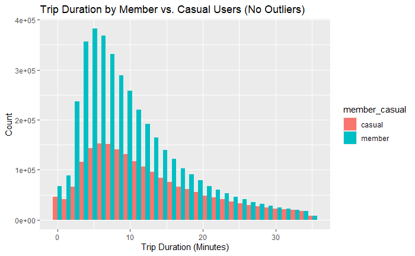

```r
ggplot(trips_no_outliers, aes(x = trip_duration, fill = member_casual)) +
  geom_histogram(position = "dodge") +
  labs(title = "Trip Duration by Member vs. Casual Users (No Outliers)", x = "Trip Duration (Minutes)", y = "Count")
```